# Activity 2

Nathan Diekema

9/23/2021

```r
library(tidyverse)
library(patchwork)
collegedata <- read_csv("data/colleges_clean.csv")
head(collegedata)
```

```
## # A tibble: 6 x 12
##   INSTNM            CITY    STABBR ZIP    CONTROL ADM_RATE SAT_AVG TUITIONFEE_IN
##   <chr>             <chr>   <chr>  <chr>    <dbl>    <dbl>   <dbl>         <dbl>
## 1 Alabama A & M Un~ Normal  AL     35762        1    0.903     929          9857
## 2 University of Al~ Birmin~ AL     35294~       1    0.918    1195          8328
## 3 University of Al~ Huntsv~ AL     35899        1    0.812    1322         10280
## 4 Alabama State Un~ Montgo~ AL     36104~       1    0.979     935         11068
## 5 The University o~ Tuscal~ AL     35487~       1    0.533    1278         10780
## 6 Auburn Universit~ Montgo~ AL     36117~       1    0.825    1083          8020
## # ... with 4 more variables: TUITIONFEE_OUT <dbl>, UGDS <dbl>, REGION <dbl>,
## #   TUITION_DIFF <dbl>
```

**1. How many private and public schools are there in your data?**

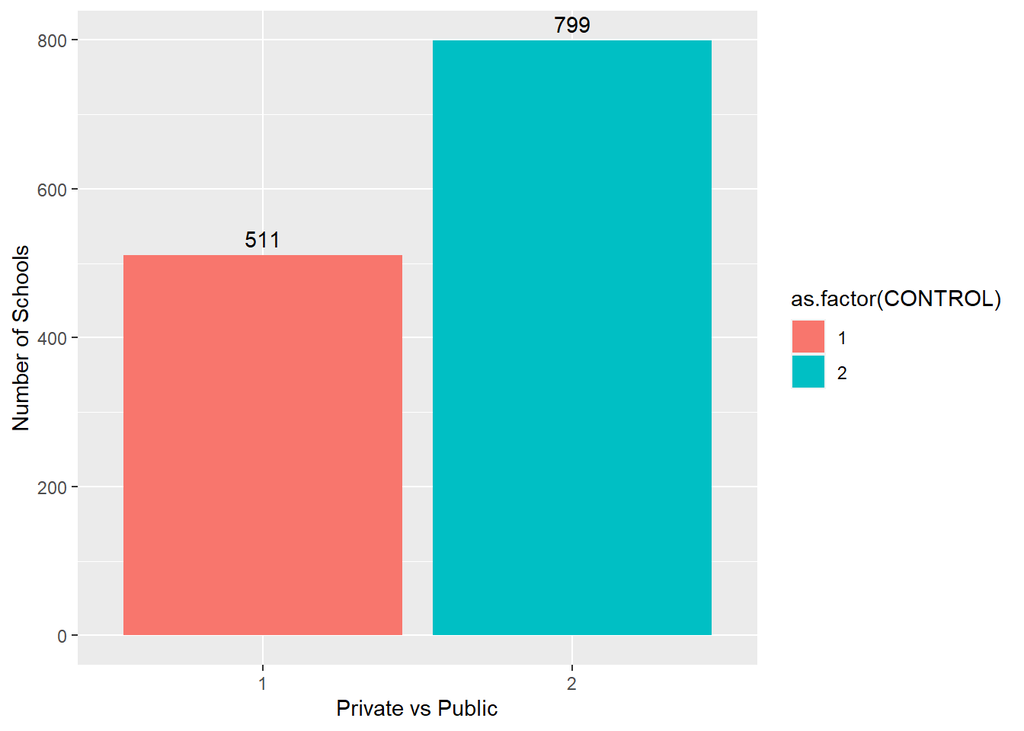

```r
plot1 <- ggplot(data=collegedata, aes(x=as.factor(CONTROL), fill=as.factor(CONTROL))) +
  geom_bar(stat="count") +
  geom_text(stat="count", aes(label=..count.., vjust=-0.5)) +
  xlab("Private vs Public") +
  ylab("Number of Schools")

plot1
```

Based on the bar chart above, it can easily be observed that there are 511 public schools and 799 private schools in this dataset

**2. What is the overall average SAT Score?**

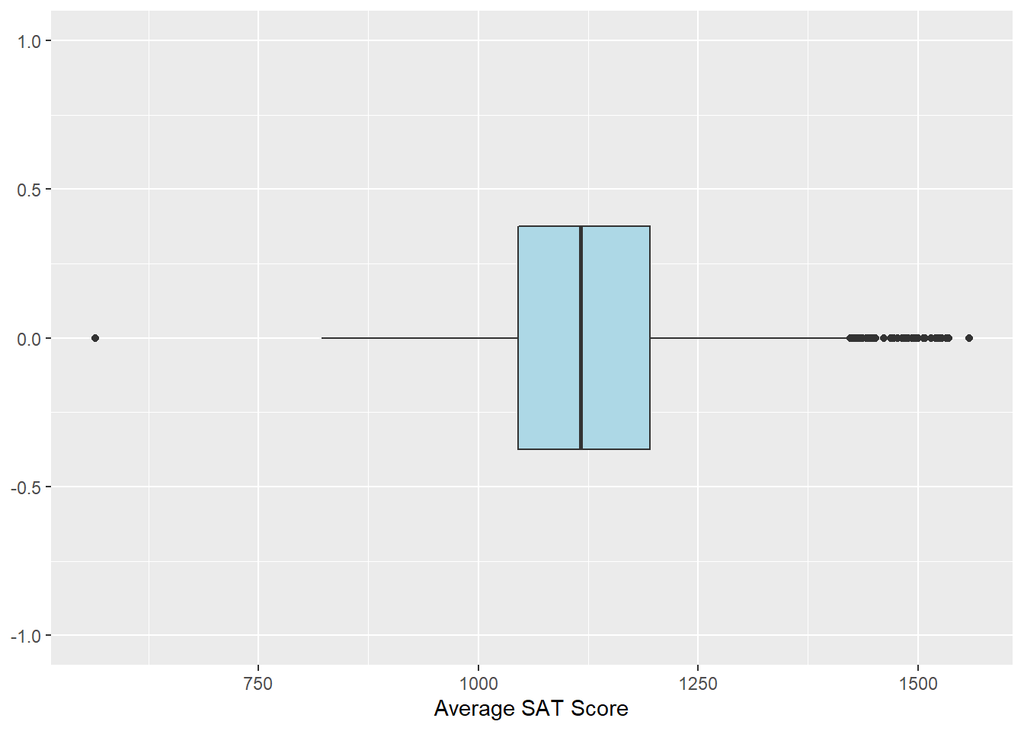

```r
plot2 <- ggplot(data=collegedata, aes(x=SAT_AVG)) +
  geom_boxplot(fill="lightblue") +
  ylim(-1,1) +
  xlab("Average SAT Score")

plot2
```

The box plot above illustrates the average SAT score across all universities in the dataset. The average SAT score is approximately 1130.

**3. What is the average SAT score for Private and Public schools?**

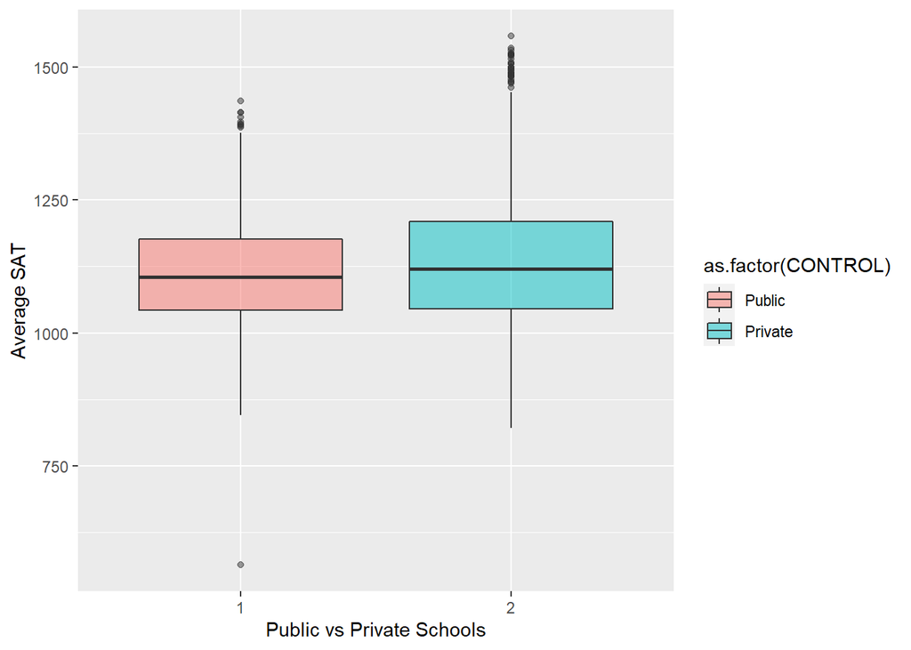

```r
plot3 <- ggplot(data=collegedata, aes(x=as.factor(CONTROL), y=SAT_AVG, fill=as.factor(CONTROL))) +
  geom_boxplot(alpha=0.5) +
  scale_fill_discrete(labels = c("Public", "Private")) +
  ylab("Average SAT") +
  xlab("Public vs Private Schools")

plot3;
```

```r
mean(data.matrix(collegedata[collegedata$CONTROL==1, "SAT_AVG"]));
```

```
## [1] 1115.284
```

```r
mean(data.matrix(collegedata[collegedata$CONTROL==2, "SAT_AVG"]));
```

```
## [1] 1141.558
```

The box chart above compares the distrubution of average SAT scores across both public and private universities. The average SAT score for public universities is approximately 1115 and the average for private universities is approximately 1141.

**4. Which school has the largest difference betweeen In- and Out-of-State tuition?**

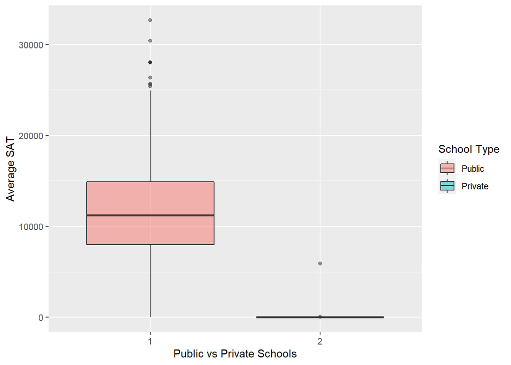

```r
plot4 <- ggplot(data=collegedata, aes(x=as.factor(CONTROL), y=TUITION_DIFF, fill=as.factor(CONTROL))) +
  geom_boxplot(alpha=0.5) +
  scale_fill_discrete(name="School Type", labels = c("Public", "Private")) +
  ylab("Average SAT") +
  xlab("Public vs Private Schools")

plot4
```

From the plot above it is clear that the difference between in-state and out-of-state tuition varies far more for public universties than private universities. This makes sense because typically private universities are the same price for both in-state and out-of-state students

**5. Are “better” schools more expensive?**

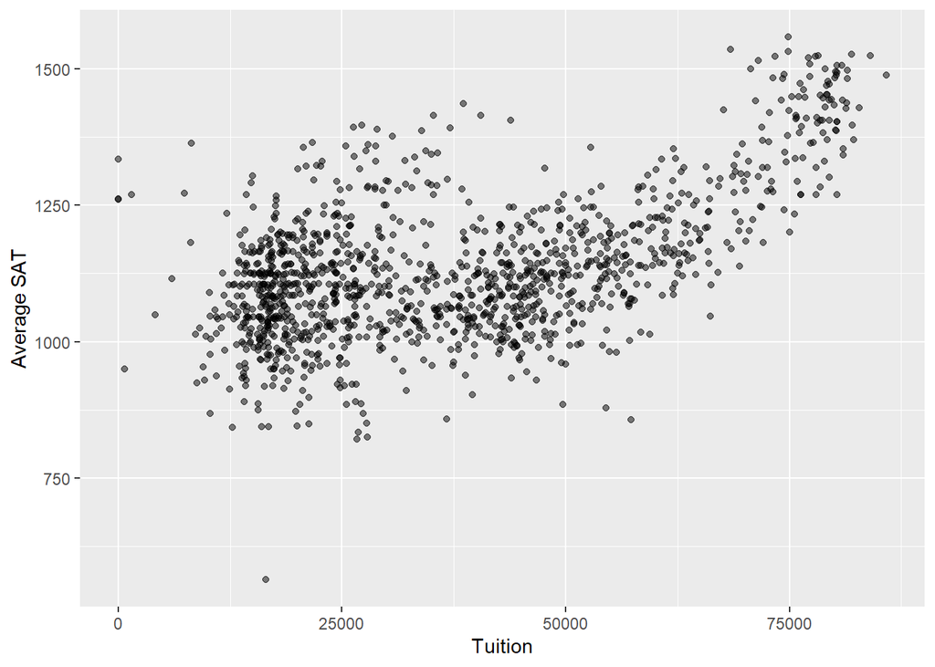

```r
plot5 <- ggplot(data=collegedata, aes(x=TUITIONFEE_IN+TUITIONFEE_OUT/2, y=SAT_AVG), color="lightblue") +
  geom_point(alpha=0.5) +
  scale_color_discrete(name="School Type", labels = c("Public", "Private")) +
  ylab("Average SAT") +
  xlab("Tuition")

plot5
```

**6. Which states tend to have the “best deals” of colleges?**

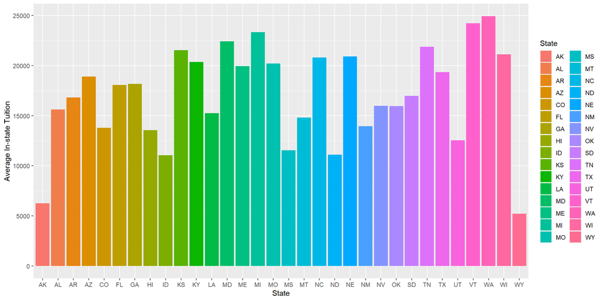

```r
collegedata %>%
  group_by(STABBR) %>%
  filter(mean(SAT_AVG) > 1068) %>%
  filter(mean(TUITIONFEE_IN) < 25000) %>%
  ggplot(aes(x=STABBR, y=TUITIONFEE_IN, fill=as.factor(STABBR))) +
  geom_bar(position="dodge", stat="summary", fun="mean") +
  scale_fill_discrete(name="State") +
  ylab("Average In-state Tuition") +
  xlab("State")
```

**7. Do different regions have different public and private school distributions?**

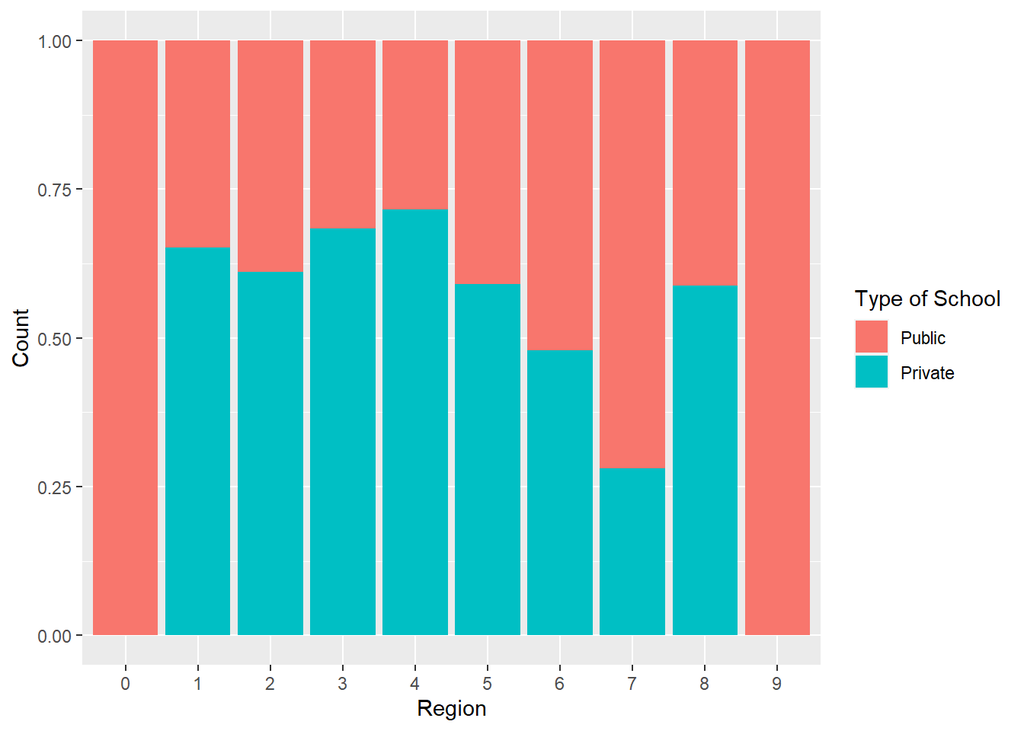

```r
plot7 <- ggplot(data=collegedata, aes(x=as.factor(REGION), fill=as.factor(CONTROL))) +
  geom_bar(position="fill") +
  scale_fill_discrete(name="Type of School", labels = c("Public", "Private")) +
  ylab("Count") +
  xlab("Region")

plot7;
```

The stacked bar chart above illustrates the distribution (as a percentage) of public to private schools in each region. As you can see each region varies with respect to distribution of type of school.

**8. How does the size of the school relate to the cost, correcting for public versus private status?**

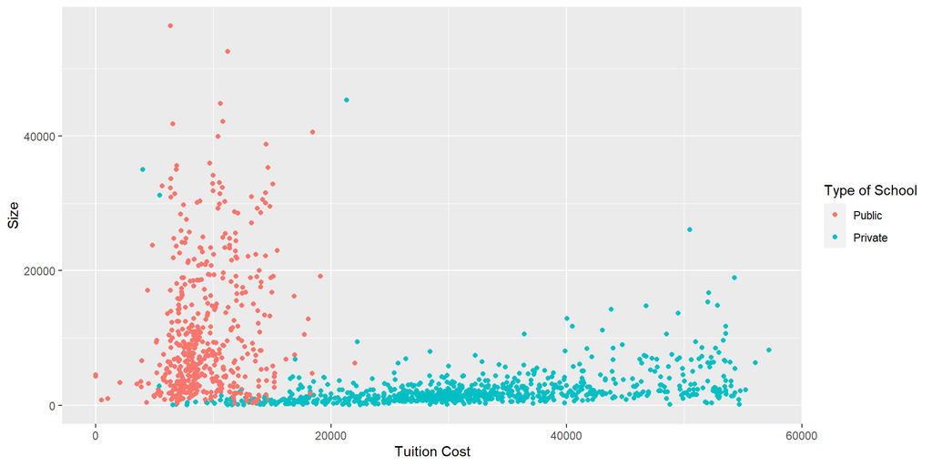

```r
plot8 <- ggplot(data=collegedata, aes(x=TUITIONFEE_IN, y=UGDS, color=as.factor(CONTROL))) +
  geom_point() +
  scale_color_discrete(name="Type of School", labels = c("Public", "Private")) +
  ylab("Size") +
  xlab("Tuition Cost")

plot8;
```

The scatter plot above illustrates the relationship between tuition and size of the school. There is a clear trend when comparing public and private schools with respect to these variables. Public schools are generally within the same price range but vary greatly in terms of size. Public schools are typically far larger than private schools. Private schools vary in price far more than public schools and are typically far smaller than public schools.

**9. Recreation of plot on worksheet**

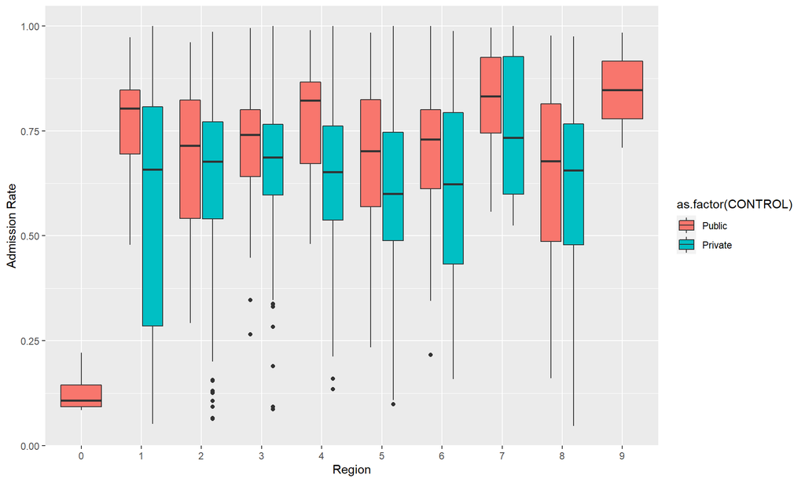

```r
plot9 <- ggplot(data=collegedata, aes(x=as.factor(REGION), y=ADM_RATE, fill=as.factor(CONTROL))) +
  geom_boxplot() +
  scale_fill_discrete(labels = c("Public", "Private")) +
  ylab("Admission Rate") +
  xlab("Region")

plot9;
```